# Faza2

Alicja Gosiewska, Gabriela Jaworska, Izabela Lis

31 maja 2016

Celem naszej prezentacji jest wybór najlepszych zmiennych do predykcji nowych przypadków nowotworu. Przedstawimy w niej przypadek konkretnego raka - nowotworu tarczycy (C73).

# Fakty dotyczące nowotworu tarczycy

Rak tarczycy jest to stosunkowo rzadki nowotwór złośliwy, stanowiący ok. 1% wszystkich przypadków zachorowań. Zazwyczaj chorzy to osoby młode, między 20 a 40 rokiem życia. Ponadto częściej diagnozowany jest u kobiet niż mężczyzn. W przypadku dzieci jest to jedna trzecia zachorowań na raka.

Przyczyny nowotworu tarczycy:

- niedobór lub nadmiar jodu
- działanie promieniowania jonizującego
- czynniki genetyczne
- nadmierna stymulacja tarczycy przez TSH

W przypadku podejrzenia zachorowania na raka podstawowa profilaktyka w Polsce opiera się na dwóch metodach:

1. wycięcie tarczycy, a następnie zbadanie jej pod kątem nowotworu,
2. wykonanie biopsji i zbadanie wyciętego fragmentu tarczycy.

# Motywacje wyboru zbioru danych

Nasuwa się pytanie - dlaczego taki, a nie inny wybór danych? Jeśli chodzi o geograficzne uwarunkowania zachorowalności na ten typ nowotworu, to pierwsze skojarzenia z tarczycą i jej chorobami nasuwają wniosek, że na obszarach, gdzie powietrze jest bogate w jod, liczba zachorowań powinna być zdecydowanie niższa. Ponadto, mając na uwadze awarię reaktora w Czarnobylu i związany z nimi wzrost zachorowań na choroby tarczycy głównie na terenie Białorusi, ale także Ukrainy nasuwa się wniosek, że ludność zamieszkująca obszary leżące tuż przy wschodniej granicy naszego kraju (województwa podlaskie, lubelskie i podkarpackie) może być bardziej narażona na niekorzystne skutki tamtego zdarzenia. Nasze przewidywania nie do końca zostały potwierdzone przez statystyczne dane:

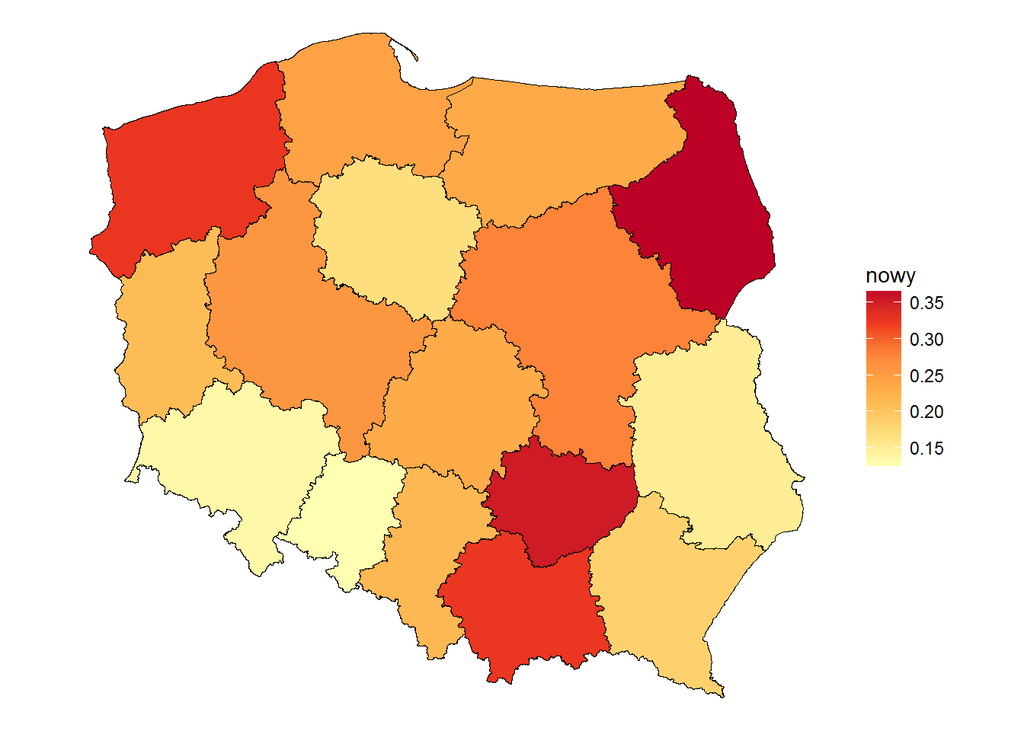

Na mapie widać znaczącą liczbę zachorowań w województwie podlaskim. Może to być spowodowane awarią reaktora w Czarnobylu (powszechnie wiadome jest, że skutki tego wydarzenia mogą być najbardziej odczuwalne dopiero po ok. 20-30 latach od awarii). Ponadto sporą zachorowalność można zauważyć w województwie zachodniopomorskim i małopolskim. Przy niemieckiej granicy (głównie województwo dolnośląskie) zauważa się odwrotną sytuację - liczba nowych przypadków zachorowań jest mniejsza, co może być związane z wyjazdami tamtejszych mieszkańców na leczenie w Niemczech.

Przyczyny takiego stanu rzeczy mogą być różne. Po pierwsze, wzrost zachorowań może być spowodowany przez duży wskaźnik urbanizacji - w miastach, znajdują się bloki z “wielkiej płyty”, które przyczyniają się do pewnego napromieniowania ludności tam mieszkającej. Po drugie, spora liczba wykrywalności zachorowań w województwie podlaskim może być spowodowana tym, że w tamtych rejonach więcej ludzi ogólnie ma problemy z tarczycy, częściej się badają, pozostają pod opieką endokrynologów, więc istnieje większa szansa na to, że rak zostanie wykryty. Po trzecie, dysproporcje między województwem podlaskim a lubelskim mogą być spowodowane przemieszczaniem się substancji radioaktywnych po awarii reaktora (w Mikołajkach odnotowano pierwsze przypadki aktywności izotopów promieniotwórczych w powietrzu, ponad pół miliona razy większej niż normalnie).

# Regresja liniowa i analiza wyników

Do wyjaśnienia częstości występowania nowotworu tarczycy, postanowiłyśmy wykorzystać zmienne takie jak płeć, przedział wiekowy oraz stopa urbanizacji. Dane dotyczące stopy urbanizacji dla poszczególnych powiatów pochodzą ze strony GUS.

```r
#lasso
#stopa urbanzacji
dane_lm<-as.data.frame(dane1[,c(2,7,13,15:20)])
dane_lm$stopa_urb<-as.numeric(dane_lm$stopa_urb)/10000

model_lm <- lm(nowy~.,data=dane_lm)
coef(model_lm)
```

```
## (Intercept)        PLEC   stopa_urb    `<0-44>`   `<45-54>`   `<55-64>`
##  -1.5520592   1.2622141   2.7670057   1.6968627   1.1896969   1.4361471
##   `<65-74>`   `<75-84>`       `85+`
##   0.9262186   0.3880058          NA
```

Badając wpływ wieku na naszą zmienną objaśnianą otrzymujemy, że jedna zmienna jest liniowo zależna od pozostałych, więc bez jej odrzucenia nie otrzymamy jednoznacznego rozwiązania.

```r
dane_lm<-dane_lm[,-c(9)]

model_lm <- lm(nowy~.,data=dane_lm)
coef(model_lm)
```

```
## (Intercept)        PLEC   stopa_urb    `<0-44>`   `<45-54>`   `<55-64>`
##  -1.5520592   1.2622141   2.7670057   1.6968627   1.1896969   1.4361471
##   `<65-74>`   `<75-84>`
##   0.9262186   0.3880058
```

Dla poszczególnych modeli policzyłyśmy błąd średniokwadratowy i przedstawiłyśmy go na wykresie skrzypcowym.

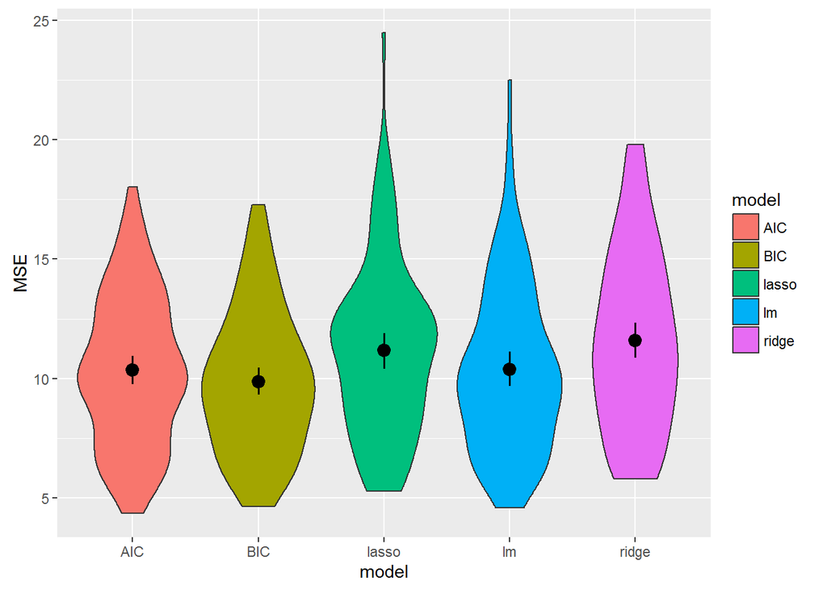

```r
ggplot(wynik_total,aes(x=model,MSE))+geom_violin(aes(fill=model))+ stat_summary(fun.data = "mean_cl_boot", colour = "black", size = 0.7)
```

Ponieważ przy zastosowaniu kryterium BIC otrzymałyśmy najniższy błąd średniokwadratowy, postanowiłyśmy ostatecznie wykorzystać ten model do objaśnienia naszej zmiennej. Wszystkie zmienne okazały się istotne.

Kryterium AIC ma tendencję do wybierania modelu ze zbyt dużą liczbie parametrów. Jeśli bardziej zależy nam na precyzji predykcji powinniśmy wykorzystać kryterium AIC, podczas gdy jeśli priorytetem jest jakość dopasowania modelu od danych należy wybrać BIC.

```r
summary(model_AIC<-step(model_lm, direction="both", k=2, trace=FALSE))
```

```
##
## Call:
## lm(formula = nowy ~ PLEC + stopa_urb + `<0-44>` + `<45-54>` +
##     `<55-64>` + `<65-74>`, data = dane_lm)
##
## Residuals:
##    Min     1Q Median     3Q    Max
## -3.336 -1.237 -0.460  0.405 65.827
##
## Coefficients:
##             Estimate Std. Error t value Pr(>|t|)
## (Intercept)  -1.2203     0.2029  -6.015 1.95e-09 ***
## PLEC          1.2598     0.1127  11.180  < 2e-16 ***
## stopa_urb     2.7667     0.1674  16.528  < 2e-16 ***
## `<0-44>`      1.3670     0.1775   7.700 1.69e-14 ***
## `<45-54>`     0.8599     0.1850   4.647 3.47e-06 ***
## `<55-64>`     1.1062     0.1810   6.112 1.07e-09 ***
## `<65-74>`     0.5964     0.1913   3.117  0.00184 **
## ---
## Signif. codes:  0 '***' 0.001 '**' 0.01 '*' 0.05 '.' 0.1 ' ' 1
##
## Residual standard error: 3.242 on 4231 degrees of freedom
## Multiple R-squared:  0.09083,    Adjusted R-squared:  0.08954
## F-statistic: 70.45 on 6 and 4231 DF,  p-value: < 2.2e-16
```

```r
summary(model_BIC<-step(model_lm, direction="both", k=log(nrow(dane_lm)), trace=FALSE))
```

```
##
## Call:
## lm(formula = nowy ~ PLEC + stopa_urb + `<0-44>` + `<45-54>` +
##     `<55-64>` + `<65-74>`, data = dane_lm)
##
## Residuals:
##    Min     1Q Median     3Q    Max
## -3.336 -1.237 -0.460  0.405 65.827
##
## Coefficients:
##             Estimate Std. Error t value Pr(>|t|)
## (Intercept)  -1.2203     0.2029  -6.015 1.95e-09 ***
## PLEC          1.2598     0.1127  11.180  < 2e-16 ***
## stopa_urb     2.7667     0.1674  16.528  < 2e-16 ***
## `<0-44>`      1.3670     0.1775   7.700 1.69e-14 ***
## `<45-54>`     0.8599     0.1850   4.647 3.47e-06 ***
## `<55-64>`     1.1062     0.1810   6.112 1.07e-09 ***
## `<65-74>`     0.5964     0.1913   3.117  0.00184 **
## ---
## Signif. codes:  0 '***' 0.001 '**' 0.01 '*' 0.05 '.' 0.1 ' ' 1
##
## Residual standard error: 3.242 on 4231 degrees of freedom
## Multiple R-squared:  0.09083,    Adjusted R-squared:  0.08954
## F-statistic: 70.45 on 6 and 4231 DF,  p-value: < 2.2e-16
```

U kobiet jest wyższe ryzyko zachorowania na nowotwór tarczycy niż u mężczyzn. Współczynnik stojący przy zmiennej stopa urbanizacji jest dość wysoki i wynosi 2,76. Oznacza to, że osoby mieszkające na obszarach wysoko zurbanizowanych są bardziej narażone na zachorowanie niż osoby zamieszkujące tereny o niższym wskaźniku urbanizacji. Widzimy też, że ryzyko zachorowania na nowotwór tarczycy jest największe w przedziale 0-44 lata i z reguły zmniejsza się z wiekiem.

Niestety współczynnik dopasowania naszego modelu jest bardzo mały, wynosi jedynie około 10%, co oznacza, że tylko 10% wariancji zmiennej objasnianej można przewidzieć z naszych zmiennych objaśniających. Może to być spowodowane małą ilością informacji o poszczególnych osobach. Z dostępnej literatury wynika, że duży wpływ na prawdopodobieństwo zachorowania mają uwarunkowania genetyczne, indywidualne predyspozycje oraz inne losowe czynniki, zatem dane dotyczące wieku, płci oraz miejsca zamieszkania jedynie w niewielkim stopniu mogą wyjaśnić fakt zachorowania na ten rodzaj nowotworu.